# Gebesee handson

Thomas Wutzler

2023-07-23

# uStar Threshold estimation

## Preparing the data

First, the data is loaded. This example uses data that has been downloaded from http://www.europe-fluxdata.eu and preprocessed by `fLoadEuroFlux16`, where the DateTime Column has been created, and the variables renamed to the BGC-convention (e.g. Tair instead of Ta).

```r
summary(DEGebExample)
```

```
    DateTime                        NEE              Ustar             Tair
 Min.   :2004-01-01 00:30:00   Min.   :-49.919   Min.   :0.0000   Min.   :-16.710
 1st Qu.:2004-10-01 00:22:30   1st Qu.: -1.864   1st Qu.:0.0640   1st Qu.:  3.360
 Median :2005-07-02 00:15:00   Median :  0.635   Median :0.1490   Median :  9.970
 Mean   :2005-07-02 00:15:00   Mean   : -1.935   Mean   :0.1884   Mean   :  9.664
 3rd Qu.:2006-04-02 00:07:30   3rd Qu.:  1.834   3rd Qu.:0.2800   3rd Qu.: 15.520
 Max.   :2007-01-01 00:00:00   Max.   : 19.008   Max.   :2.0450   Max.   : 34.680
                               NA's   :21849     NA's   :1149
       rH               Rg               VPD
 Min.   : 15.87   Min.   :   0.00   Min.   : 0.000
 1st Qu.: 66.61   1st Qu.:   0.00   1st Qu.: 1.106
 Median : 79.10   Median :   2.04   Median : 2.246
 Mean   : 75.24   Mean   : 124.71   Mean   : 4.136
 3rd Qu.: 87.07   3rd Qu.: 176.03   3rd Qu.: 5.027
 Max.   :100.00   Max.   :1046.03   Max.   :44.321
 NA's   :1                          NA's   :1
```

VPD was not given with the original dataset and is calculated from Tair and rH.

## Task 1a: Create the REddyProc class

named `EProc` with columns c(‘NEE’,‘Rg’,‘Tair’,‘VPD’, ‘Ustar’)

at Location LatDeg = 51.1, LongDeg = 10.9,

and timezone one hour adead of GMT (TimeZoneHour = 1)

```r
### TO_COMPLETE
EProc <- sEddyProc$new('DE-Geb', DEGebExample, c('NEE','Rg','Tair','VPD', 'Ustar'))
```

```
New sEddyProc class for site 'DE-Geb'
```

## Defining Seasons with different surface friction conditions

The site is a crop site. The harvesting times are visible as sharp edges in the plots of NEE.

The micrometeorological conditions differ between the different cropping periods, because the friction at the surface differs. Also not the cropping periods do not correspond very well to seasons. Hence, for the estimation of uStar-Thresholds, we apply a user-defined splitting of uStar-seasons. With function `usCreateSeasonFactorYdayYear` we provide the starting points of the seasons.

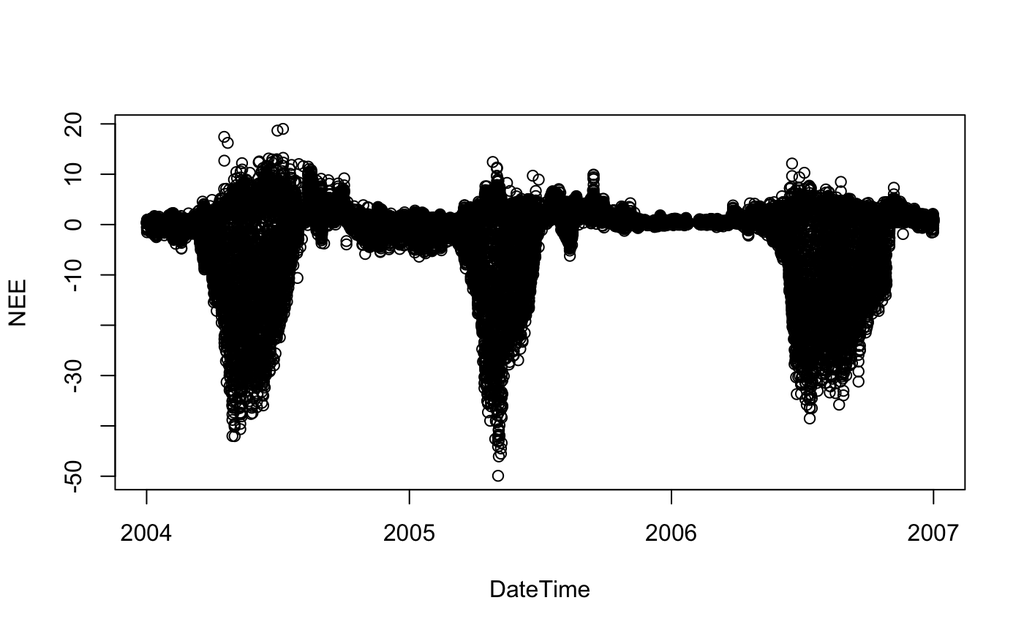

## Task 1b: Define sesason

Base on the NEE plot define seasons with starting at day 70, 210, 320 in 2004 and 70,180,320 in 2005 and 120,305 in 2006

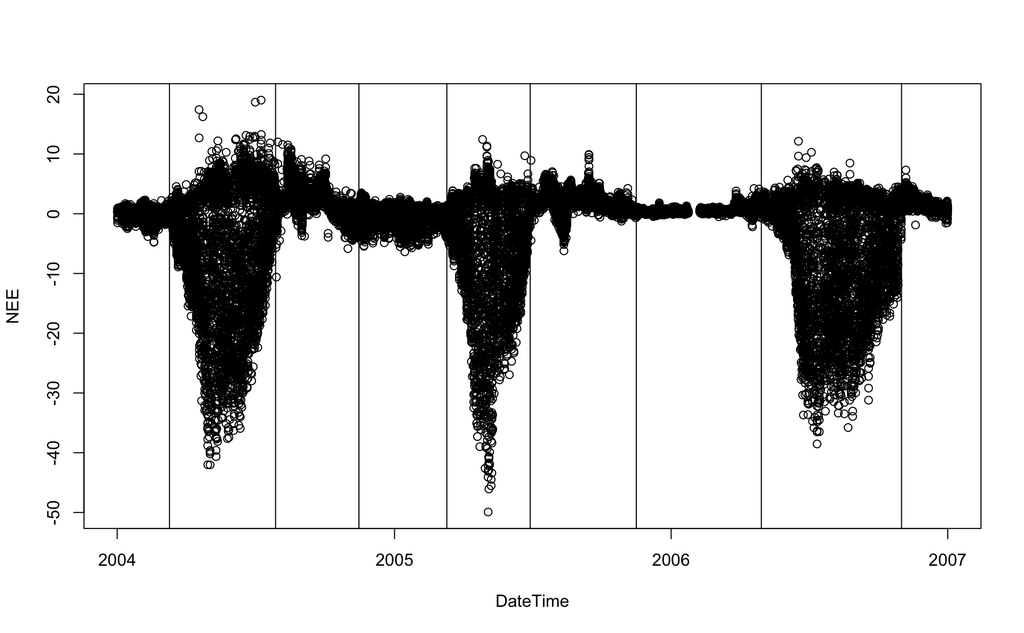

## Task 1c: Estimate the distribution of u* thresholds

Specify the seasons defined before.

For saving time, here use only 30 bootstrap samples (argument nSample) and estimate only the 10th and 90th percentile (argument probs)

Print the estimated thresholds.

| aggregationMode | seasonYear | season | uStar | 10% | 90% |
| --- | --- | --- | --- | --- | --- |
| single | NA | NA | 0.16041176 | 0.13858186 | 0.17335714 |
| year | 2004 | NA | 0.13500000 | 0.12650722 | 0.18808750 |
| year | 2005 | NA | 0.16041176 | 0.12345667 | 0.17335714 |
| year | 2006 | NA | 0.25094444 | 0.06278182 | 0.26309653 |
| season | 2004 | 2004001 | 0.13500000 | 0.11045318 | 0.14517318 |
| season | 2004 | 2004070 | 0.12037500 | 0.09143125 | 0.12093250 |
| season | 2004 | 2004210 | 0.08925000 | 0.08922500 | 0.18808750 |
| season | 2005 | 2004320 | 0.16041176 | 0.09814393 | 0.16183331 |
| season | 2005 | 2005070 | 0.12533333 | 0.11901667 | 0.17290476 |
| season | 2005 | 2005180 | 0.13473214 | 0.08106250 | 0.14151364 |

[output cut: 3 more lines]

# Gapfilling

## Task 2a: Use seasonal u* thresholds

- display the default annually used thresholds
- specify using seasonsal thresholds
- display the scenarios again

|  | season | uStar | U10 | U90 |
| --- | --- | --- | --- | --- |
| 5 | 2004001 | 0.13500000 | 0.11045318 | 0.14517318 |
| 6 | 2004070 | 0.12037500 | 0.09143125 | 0.12093250 |
| 7 | 2004210 | 0.08925000 | 0.08922500 | 0.18808750 |
| 8 | 2004320 | 0.16041176 | 0.09814393 | 0.16183331 |
| 9 | 2005070 | 0.12533333 | 0.11901667 | 0.17290476 |
| 10 | 2005180 | 0.13473214 | 0.08106250 | 0.14151364 |
| 11 | 2005320 | 0.04842361 | 0.04697333 | 0.08154625 |
| 12 | 2006120 | 0.06966667 | 0.05855000 | 0.08279615 |
| 13 | 2006305 | 0.25094444 | 0.10557778 | 0.26309653 |

## Task 2b: Perform gapfilling for NEE

Estimate random error also for non-gap records.

What columns have been created?

```r
colnames(EProc$sExportResults())
```

```
 [1] "season"            "Ustar_uStar_Thres" "Ustar_uStar_fqc"   "NEE_uStar_orig"
 [5] "NEE_uStar_f"       "NEE_uStar_fqc"     "NEE_uStar_fall"    "NEE_uStar_fall_qc"
 [9] "NEE_uStar_fnum"    "NEE_uStar_fsd"     "NEE_uStar_fmeth"   "NEE_uStar_fwin"
[13] "Ustar_U10_Thres"   "Ustar_U10_fqc"     "NEE_U10_orig"      "NEE_U10_f"
[17] "NEE_U10_fqc"       "NEE_U10_fall"      "NEE_U10_fall_qc"   "NEE_U10_fnum"
[21] "NEE_U10_fsd"       "NEE_U10_fmeth"     "NEE_U10_fwin"      "Ustar_U90_Thres"
[25] "Ustar_U90_fqc"     "NEE_U90_orig"      "NEE_U90_f"         "NEE_U90_fqc"
[29] "NEE_U90_fall"      "NEE_U90_fall_qc"   "NEE_U90_fnum"      "NEE_U90_fsd"
[33] "NEE_U90_fmeth"     "NEE_U90_fwin"
```

For an explanation of the column names see [output format description](https://www.bgc-jena.mpg.de/bgi/index.php/Services/REddyProcWebOutput) - NEE_*f: gaps replaced by modeled values (gapfilled) - NEE**fall: all NEE replaced by modeled values - NEE*_fqc: quality flag: 0 observations, 1 good quality of gapfilling

## Task 2c: Produce a fingerprint plot of gapfilled values

First a single plot in document - for 90% quantile $u_{*Th}$ (suffix U90) - for year 2005

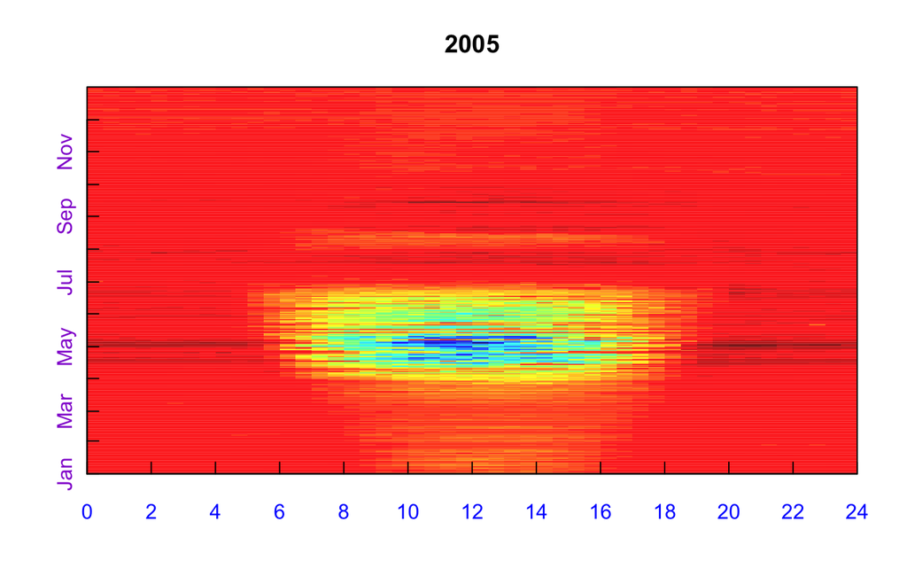

Next, produce pdf-files with legend for all years in subdirectory “plotsHandsOn”

```r
### TO_COMPLETE
EProc$sPlotFingerprint('NEE_U90_f', Dir = "plotsHandsOn")
```

```
sPlotFingerprint:::.self$.sxOpenPlot:::fSetFile::: Directory created: plotsHandsOn
```

# Flux partitioning

## Task 3a: Prepare for partitioning

Gapfill the necessary meteorological input variables (Rg, Tair, VPD). Here we do not need computing the uncertainty of the non-filled records.

## Task 3b: Nighttime partitioning

Perform the nighttime partitioning

## Task 3c: Plotting the head GPP

Query the result data.frame to variable dsResults

Plot the head of GPP for U90 scenario against time (DEGebExample$DateTime)

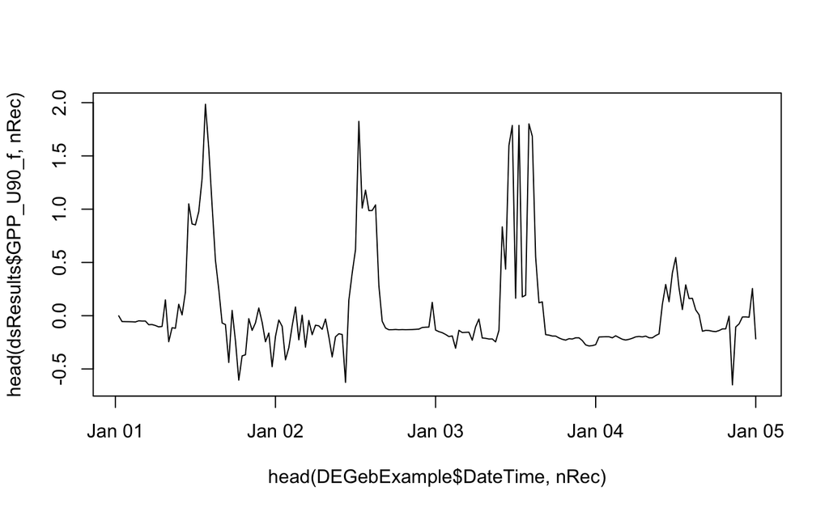

## Task3d: Daytime partitioning

Perform the daytime partitioning.

```r
### TO_COMPLETE
EProc$sGLFluxPartitionUStarScens()
```

Bonus Task: Repeat with fixed Temperature Senstivity to 80 $$40 K

```r
?partGLControl
### TO_COMPLETE
EProc$sGLFluxPartitionUStarScens(
  controlGLPart = partGLControl(
    fixedTempSens = data.frame(E0 = 80, sdE0 = 40, RRef = NA_real_))
  ,isWarnReplaceColumns = FALSE
)
```

## Task 3e: Produce fingerprint plots of GPP_DT and Reco_DT

- For the original non-bootstrapped data uStar scenario (suffix uStar)
- In Sub-Directory `plotsHandsOn`

## Task 3f: Save the results together with the data

as tab-delimted text file “plotsHandsOn/DEGeb_Part.txt” Store the combined data and results in variable ‘results’

```r
fWriteDataframeToFile(results, "DE-Geb_Part.txt", Dir = "plotsHandsOn")
```

```
Number of NA convertered to '-9999': 1772143
Wrote tab separated textfile: plotsHandsOn/DE-Geb_Part.txt
```

# Bias with $u_{*Th}$

## Focus on year 2005

## Task 4a: compute the annual mean NEE for each $u_{*Th}$ scenario

For the mean we can use gap-filled series in column `NEE_<suffix>_f`

```r
NEE_UStar
```

```
     uStar        U10        U90
-0.3610869 -0.3966197 -0.3568312
```

## Task 4b: Compute statistic across the obtained aggregates

```r
### TO_COMPLETE
c(mean(NEE_UStar), sd(NEE_UStar), sd(NEE_UStar)/abs(mean(NEE_UStar)))
```

# Random uncertainty aggregation

## Task 5a: approximate the error terms in results

For each good measurement, i.e. where `NEE_uStar_fqc == 0` we have measured NEE that includes random fluctuation `NEE_uStar_orig` and gap-filling estimate `NEE_uStar_fall` of the expected flux for the conditions at this time.

Create a new column `resid` that stores the difference for good conditions and NA for other records.

```r
n <- sum(results$NEE_uStar_fqc == 0)  # number of good records
?ifelse
### TO_COMPLETE
results$resid = ifelse(
  results$NEE_uStar_fqc == 0, results$NEE_uStar_orig - results$NEE_uStar_fall, NA )
```

## Task 5b: compute the empirical autocorrelation function

```r
library(lognorm)
?computeEffectiveAutoCorr
### TO_COMPLETE
rho = computeEffectiveAutoCorr(results$resid)
plot(rho[-1])
```

## Task 5c: Compute the effective number of effice observation

To variable `nEff`

and compare to the number of good observations `n`.

```r
?computeEffectiveNumObs
### TO_COMPLETE
nEff <- computeEffectiveNumObs(results$resid, na.rm = TRUE)
c(nEff, n)
```

## Task 5d: Compute its effective number of observations for year 2005

Use the autocorrelation function that you determined on the entire dataset before (`rho`)

```r
?computeEffectiveNumObs # note argument effAcf
### TO_COMPLETE
nEff <- computeEffectiveNumObs(res05$resid, na.rm = TRUE, effAcf = rho)
```

## Task 5e Compute the mean annual NEE and its standard deviation for 2005

For scenario $u_{*Th}$ threshold scenario `uStar` Report also the relative error, i.e. coefficient of variation.

Consider gap-filled values in the mean. But make sure to not use gap-filled records in unertainty estimation.

Remember that the root-mean-squared averaged standard deviation decreases by factor $\sqrt{nEff -1}$.

```r
sdGood = res05$NEE_uStar_fsd[res05$NEE_uStar_fqc == 0]
### TO_COMPLETE
NEE = mean(res05$NEE_uStar_f)
sdNEE = sqrt(mean(sdGood^2)) / sqrt(nEff - 1)
c(mean = NEE, sd = sdNEE, cv = sdNEE/abs(NEE))
```

# Combined uncertainty

## Task 6a Compute the combined uncertaint of random and $u_{*Th}$

Remember that standard deviation of independent variables adds in squares.

```r
sdNEEUStar = sd(NEE_UStar)
sdNEECombined <-
### TO_COMPLETE
   sqrt(sdNEEUStar^2 + sdNEE^2)
sdNEECombined
```